# Heart Failure Prediction

Katarina Virijević i Ivana Dragović

## Uvod

Odabrani skup podataka “Heart Failure Prediction” sadrži podatke o ispitanicima sa potencijalno oslabljenim radom srca. Ljudima sa kardiovaskularnim oboljenjima ili koji su pod visokim kardiovaskularnim rizikom (zbog prisustva jednog ili više faktora rizika - hipertenzija, dijabetes, hiperlipidemija ili već ustanovljena bolest) potrebno je rano otkrivanje i lečenje, pri čemu model mašinskog učenja može biti od velike pomoći. Dostupne podatake i parametare koristićemo u svrhu predviđanja smrtnosti nastale usled otkazivanja srca.

## Opis podataka

Skup podataka sastoji se od 13 atributa i 315 primera. Imena atributa i njigova značenja data su u nastavku:

#### Numeričke promenljive

- **Age** - Godine ispitanika
- **Creatinine_phosphokinase** - Količina CPK enzima (kreatin kinaza) u krvi (mcg/L)
- **Ejection_fraction** - Procenat krvi koja napušta srce pri svakoj kontrakciji
- **Platelets** - Trombociti u krvi (kiloplatelets/mL)
- **Serum_creatinine** - Nivo serumskog kreatinina u krvi (mg/dL)
- **Serum_sodium** - Nivo natrijuma seruma u krvi (mEq/L)
- **Time** - Period praćenja (izražen u danima)

#### Kategorijske promenljive

- **Anaemia** - Označava da li ispitanik ima anemiju (binarna klasifikacija - 0 ili 1)
- **Diabetes** - Označava da li ispitanik ima dijabetes (binarna klasifikacija - 0 ili 1)
- **High_blood_pressure** - Označava da li ispitanik ima povišeni krvni pritisak (binarna klasifikacija - 0 ili 1)
- **Sex** - Pol ispitanika (binarna klasifikacija - 0(žena) ili 1(muškarac))
- **Smoking** - Označava da li je ispitanik pušač (binarna klasifikacija - 0 ili 1)
- **DEATH_EVENT** - **Ciljna promenljiva**, označava da li je ispitanik preminuo tokom perioda praćenja (binarna klasifikacija - 0 ili 1)

## Učitavanje biblioteka i skupa podataka

```r
library(tidyverse)
```

```r
library(mice)
```

```r
library(VIM)
library(colorspace)
library(grid)
```

```r
library(Amelia)
```

```r
library(naniar)
```

```r
library(plotrix)
library(ggridges)
```

```r
library(vcd)
```

```r
library(rpart)
library(rpart.plot)
```

Izvršavamo učitavanje skupa podataka u promenljivu **data**:

```r
data = read.csv("C:/Users/Windows10/Documents/R/data/heart_failure_clinical_records_dataset_NA.csv")
```

Izvršenjem funkcije **dim**, dobijamo informaciju da skup podataka sadrži 315 redova i 13 kolona, kao što je već napomenuto u odeljku “**Opis podataka**”.

```r
dim(data)
```

```
[1] 315  13
```

Uz pomoć funkcije **head** možemo pregledati prvih **n** redova skupa podataka (u našem slučaju **10** redova).

```r
head(data, n=10)
```

|  | age | anaemia | creatinine_phosphokinase | diabetes | ejection_fraction | high_blood_pressure | platelets | serum_creatinine | serum_sodium | sex | smoking | time | DEATH_EVENT |
| --- | --- | --- | --- | --- | --- | --- | --- | --- | --- | --- | --- | --- | --- |
| 1 | 75 | 0 | 582 | 0 | 20 | 1 | 265000 | 1.9 | 130 | 1 | 0 | 4 | 1 |
| 2 | 55 | 0 | 7861 | 0 | 38 | 0 | 263358 | 1.1 | 136 | 1 | 0 | 6 | 1 |
| 3 | 65 | 0 | 146 | 0 | 20 | 0 | 162000 | 1.3 | 129 | 1 | 1 | 7 | 1 |
| 4 | 50 | 1 | 111 | 0 | 20 | 0 | 210000 | 1.9 | 137 | 1 | 0 | 7 | 1 |
| 5 | 65 | 1 | 160 | 1 | 20 | 0 | 327000 | 2.7 | 116 | 0 | 0 | 8 | 1 |
| 6 | 90 | 1 | 47 | 0 | 40 | 1 | 204000 | 2.1 | 132 | 1 | 1 | 8 | 1 |
| 7 | 75 | 1 | 246 | 0 | 15 | 0 | 127000 | 1.2 | 137 | 1 | 0 | 10 | 1 |
| 8 | 60 | 1 | 315 | 1 | 60 | 0 | 454000 | 1.1 | 131 | 1 | 1 | 10 | 1 |
| 9 | 65 | 0 | 157 | 0 | 65 | 0 | 263358 | 1.5 | 138 | 0 | 0 | 10 | 1 |
| 10 | 80 | 1 | 123 | 0 | 35 | 1 | 388000 | 9.4 | 133 | 1 | 1 | 10 | 1 |

```r
summary(data)
```

```
      age           anaemia       creatinine_phosphokinase    diabetes      ejection_fraction high_blood_pressure
 Min.   :40.00   Min.   :0.0000   Min.   :   0.0           Min.   :0.0000   Min.   :14.00     Min.   :0.0000
 1st Qu.:50.00   1st Qu.:0.0000   1st Qu.: 116.5           1st Qu.:0.0000   1st Qu.:30.00     1st Qu.:0.0000
 Median :60.00   Median :0.0000   Median : 253.0           Median :0.0000   Median :38.00     Median :0.0000
 Mean   :60.63   Mean   :0.4281   Mean   : 617.1           Mean   :0.4254   Mean   :37.95     Mean   :0.3524
 3rd Qu.:70.00   3rd Qu.:1.0000   3rd Qu.: 582.0           3rd Qu.:1.0000   3rd Qu.:45.00     3rd Qu.:1.0000
 Max.   :95.00   Max.   :1.0000   Max.   :7861.0           Max.   :1.0000   Max.   :80.00     Max.   :1.0000
 NA's   :1       NA's   :2                                                  NA's   :3
   platelets       serum_creatinine  serum_sodium        sex            smoking            time        DEATH_EVENT
 Min.   :  25100   Min.   :0.00     Min.   :113.0   Min.   :0.0000   Min.   :0.0000   Min.   :  4.0   Min.   :0.000
 1st Qu.: 211500   1st Qu.:0.90     1st Qu.:134.0   1st Qu.:0.0000   1st Qu.:0.0000   1st Qu.: 72.0   1st Qu.:0.000
 Median : 263000   Median :1.10     Median :137.0   Median :1.0000   Median :0.0000   Median :115.0   Median :0.000
 Mean   : 273547   Mean   :1.38     Mean   :136.5   Mean   :0.6506   Mean   :0.3238   Mean   :129.6   Mean   :0.327
 3rd Qu.: 305000   3rd Qu.:1.40     3rd Qu.:139.5   3rd Qu.:1.0000   3rd Qu.:1.0000   3rd Qu.:201.0   3rd Qu.:1.000
 Max.   :2790000   Max.   :9.40     Max.   :148.0   Max.   :1.0000   Max.   :2.0000   Max.   :285.0   Max.   :1.000
                   NA's   :2                        NA's   :3                         NA's   :2
```

Izvršavanjem funkcije **summary** dobijamo dodatne informacije o skupu podataka. Na osnovu toga možemo primetiti da nekoliko kolona skupa podataka sadrži nedostajuće vrednosti. Njima ćemo se pozabaviti kasnije u odeljku **“Rad sa nedostajućim vrednostima”**.

```r
str(data)
```

```
'data.frame':   315 obs. of  13 variables:
 $ age                     : num  75 55 65 50 65 90 75 60 65 80 ...
 $ anaemia                 : int  0 0 0 1 1 1 1 1 0 1 ...
 $ creatinine_phosphokinase: int  582 7861 146 111 160 47 246 315 157 123 ...
 $ diabetes                : int  0 0 0 0 1 0 0 1 0 0 ...
 $ ejection_fraction       : int  20 38 20 20 20 40 15 60 65 35 ...
 $ high_blood_pressure     : int  1 0 0 0 0 1 0 0 0 1 ...
 $ platelets               : num  265000 263358 162000 210000 327000 ...
 $ serum_creatinine        : num  1.9 1.1 1.3 1.9 2.7 2.1 1.2 1.1 1.5 9.4 ...
 $ serum_sodium            : int  130 136 129 137 116 132 137 131 138 133 ...
 $ sex                     : int  1 1 1 1 0 1 1 1 0 1 ...
 $ smoking                 : int  0 0 1 0 0 1 0 1 0 1 ...
 $ time                    : int  4 6 7 7 8 8 10 10 10 10 ...
 $ DEATH_EVENT             : int  1 1 1 1 1 1 1 1 1 1 ...
```

Funkcija **str** omogućava nam pregled strukture skupa podataka. Svi atributi skupa su numerički, od čega 10 atributa ima tip **int**, a preostala 3 tip **num**.

Pre nego što pređemo na pripremu podataka, za numeričke atribute koji zapravo vrše klasifikaciju dodaćemo posebne kategorijske kolone, zahvaljujući čemu ćemo moći na pogodniji način da vizuelizujemo podatke u nastavku:

```r
data$anaemia_cat<-factor(NA,levels = c(0,1),labels = c("Nema anemiju","Ima anemiju"))
data$anaemia_cat[which(data$anaemia==0)]="Nema anemiju"
data$anaemia_cat[which(data$anaemia==1)]="Ima anemiju"
```

```r
data$diabetes_cat<-factor(NA,levels = c(0,1),labels = c("Nema dijabetes","Ima dijabetes"))
data$diabetes_cat[which(data$diabetes==0)]="Nema dijabetes"
data$diabetes_cat[which(data$diabetes==1)]="Ima dijabetes"
```

```r
data$high_blood_pressure_cat<-factor(NA,levels = c(0,1),labels = c("Nema povišen krvni pritisak","Ima povišen krvni pritisak"))
data$high_blood_pressure_cat[which(data$high_blood_pressure==0)]="Nema povišen krvni pritisak"
data$high_blood_pressure_cat[which(data$high_blood_pressure==1)]="Ima povišen krvni pritisak"
```

```r
data$sex_cat<-factor(NA,levels = c(0,1),labels = c("Ž","M"))
data$sex_cat[which(data$sex==0)]="Ž"
data$sex_cat[which(data$sex==1)]="M"
```

```r
data$smoking_cat<-factor(NA,levels = c(0,1),labels = c("Ne","Da"))
data$smoking_cat[which(data$smoking==0)]="Ne"
data$smoking_cat[which(data$smoking==1)]="Da"
```

```r
data$DEATH_EVENT_cat<-factor(NA,levels = c(0,1),labels = c("Nije preminuo","Preminuo"))
data$DEATH_EVENT_cat[which(data$DEATH_EVENT==0)]="Nije preminuo"
data$DEATH_EVENT_cat[which(data$DEATH_EVENT==1)]="Preminuo"
```

```r
data$age_cat<-factor("40-50",levels = c(0,1,2,3),labels = c("40-50","51-65","66-75","75+"))
data$age_cat[data$age>=40 & data$age<=50]="40-50"
data$age_cat[data$age>50 & data$age<=65]="51-65"
data$age_cat[data$age>65 & data$age<=75]="66-75"
data$age_cat[data$age>75]="75+"
```

```r
str(data)
```

```
'data.frame':   315 obs. of  20 variables:
 $ age                     : num  75 55 65 50 65 90 75 60 65 80 ...
 $ anaemia                 : int  0 0 0 1 1 1 1 1 0 1 ...
 $ creatinine_phosphokinase: int  582 7861 146 111 160 47 246 315 157 123 ...
 $ diabetes                : int  0 0 0 0 1 0 0 1 0 0 ...
 $ ejection_fraction       : int  20 38 20 20 20 40 15 60 65 35 ...
 $ high_blood_pressure     : int  1 0 0 0 0 1 0 0 0 1 ...
 $ platelets               : num  265000 263358 162000 210000 327000 ...
 $ serum_creatinine        : num  1.9 1.1 1.3 1.9 2.7 2.1 1.2 1.1 1.5 9.4 ...
 $ serum_sodium            : int  130 136 129 137 116 132 137 131 138 133 ...
 $ sex                     : int  1 1 1 1 0 1 1 1 0 1 ...
 $ smoking                 : int  0 0 1 0 0 1 0 1 0 1 ...
 $ time                    : int  4 6 7 7 8 8 10 10 10 10 ...
 $ DEATH_EVENT             : int  1 1 1 1 1 1 1 1 1 1 ...
 $ anaemia_cat             : Factor w/ 2 levels "Nema anemiju",..: 1 1 1 2 2 2 2 2 1 2 ...
 $ diabetes_cat            : Factor w/ 2 levels "Nema dijabetes",..: 1 1 1 1 2 1 1 2 1 1 ...
 $ high_blood_pressure_cat : Factor w/ 2 levels "Nema povišen krvni pritisak",..: 2 1 1 1 1 2 1 1 1 2 ...
 $ sex_cat                 : Factor w/ 2 levels "Ž","M": 2 2 2 2 1 2 2 2 1 2 ...
 $ smoking_cat             : Factor w/ 2 levels "Ne","Da": 1 1 2 1 1 2 1 2 1 2 ...
 $ DEATH_EVENT_cat         : Factor w/ 2 levels "Nije preminuo",..: 2 2 2 2 2 2 2 2 2 2 ...
 $ age_cat                 : Factor w/ 4 levels "40-50","51-65",..: 3 2 2 1 2 4 3 2 2 4 ...
```

# Ispitivanje i vizuelizacija podataka

## Kategorijske promenljive

### Anemija

```r
summary(data$anaemia)
```

```
   Min. 1st Qu.  Median    Mean 3rd Qu.    Max.    NA's
 0.0000  0.0000  0.0000  0.4281  1.0000  1.0000       2
```

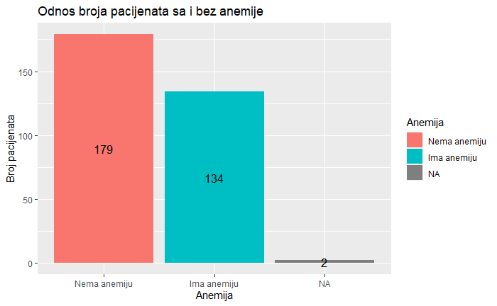

```r
ggplot(data = data, aes(x = anaemia_cat)) +
  geom_bar(stat = "count",mapping = aes(fill=anaemia_cat)) +
  stat_count(geom = "text", colour = "black", size = 4.5, aes(label = ..count..), position = position_stack(vjust = 0.5))+
  labs(title = "Odnos broja pacijenata sa i bez anemije",
       x = "Anemija",
       y = "Broj pacijenata") + guides(fill=guide_legend(title="Anemija"))
```

Sa grafika možemo primetiti da veći broj ispitanika nema anemiju. Tačan broj ispitanika koji nemaju, odnosno imaju anemiju dat je ispod uz pomoć funkcije **xtabs**:

```r
xtabs(~anaemia_cat, data=data)
```

```
anaemia_cat
Nema anemiju  Ima anemiju
         179          134
```

### Dijabetes

```r
summary(data$diabetes)
```

```
   Min. 1st Qu.  Median    Mean 3rd Qu.    Max.
 0.0000  0.0000  0.0000  0.4254  1.0000  1.0000
```

```r
xtabs(~diabetes, data=data)
```

```
diabetes
  0   1
181 134
```

Možemo primetiti da u ovoj koloni nemamo nedostajućih vrednosti, kao i da ima više ispitanika koji nemaju dijabetes. To možemo i vizuelizovati:

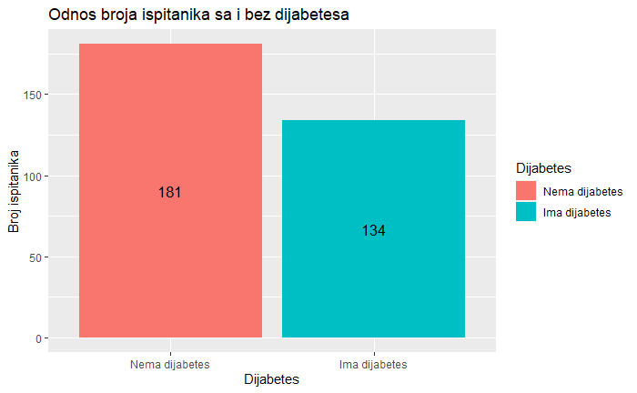

```r
ggplot(data = data, aes(x = diabetes_cat)) +
  geom_bar(stat = "count",mapping = aes(fill=diabetes_cat)) +
  stat_count(geom = "text", colour = "black", size = 4.5, aes(label = ..count..), position = position_stack(vjust = 0.5))+
  labs(title = "Odnos broja ispitanika sa i bez dijabetesa",
       x = "Dijabetes",
       y = "Broj ispitanika") + guides(fill=guide_legend(title="Dijabetes"))
```

Iako veći broj ispitanika nisu imali/nemaju dijabetes, on sam po sebi može biti uzrok oslabljenog rada srca jer veoma negativno utiče na krvne sudove.

### Hipertenzija

Kao i do sada, prvo ćemo pogledati koje vrednosti imamo u skupu za ovaj atribut:

```r
xtabs(~high_blood_pressure, data=data)
```

```
high_blood_pressure
  0   1
204 111
```

```r
summary(data$high_blood_pressure_cat)
```

```
Nema povišen krvni pritisak  Ima povišen krvni pritisak
                        204                         111
```

Na osnovu ovoga vidimo da za atribut **high_blood_pressure** nemamo nekih neočekivanih ili nedostajućih vrednosti, kao i da većina ispitanika nema povišeni krvni pritisak.

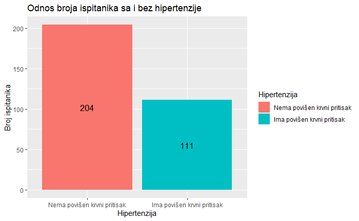

```r
ggplot(data = data, aes(x = high_blood_pressure_cat)) +
  geom_bar(stat = "count",mapping = aes(fill=high_blood_pressure_cat)) +
  stat_count(geom = "text", colour = "black", size = 4.5, aes(label = ..count..), position = position_stack(vjust = 0.5))+
  labs(title = "Odnos broja ispitanika sa i bez hipertenzije",
       x = "Hipertenzija",
       y = "Broj ispitanika") + guides(fill=guide_legend(title="Hipertenzija"))
```

### Pol

```r
xtabs(~sex, data=data)
```

```
sex
  0   1
109 203
```

```r
length(which(is.na(data$sex)))
```

```
[1] 3
```

Za parametar pol postoje tri NA vrednosti.

```r
xtabs(~sex_cat, data=data)
```

```
sex_cat
  Ž   M
109 203
```

Vidimo da u skupu podataka imamo skoro dva puta više muških nego ženskih ispitanika. Prikazaćemo i grafički.

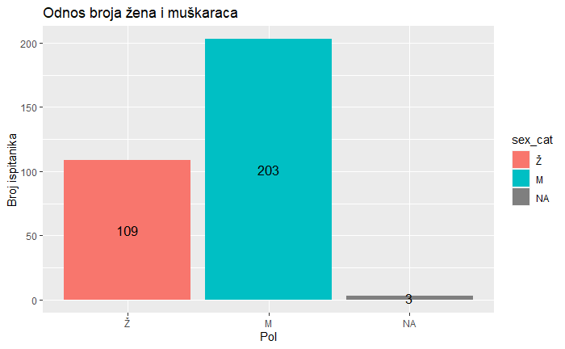

```r
ggplot(data = data, aes(x = sex_cat)) +
  geom_bar(stat = "count",mapping = aes(fill=sex_cat)) +
  stat_count(geom = "text", colour = "black", size = 4.5, aes(label = ..count..), position = position_stack(vjust = 0.5))+
  labs(title = "Odnos broja žena i muškaraca",
       x = "Pol",
       y = "Broj ispitanika")
```

### Pušenje

```r
xtabs(~smoking, data=data)
```

```
smoking
  0   1   2
214 100   1
```

Primećujemo da postoji vrednost 2 za pušenje koja nije validna jer su nepušači obeleženi sa 0 a pušači sa 1. Ovu vrednost ćemo predstaviti sa NA.

```r
data$smoking[which(data$smoking==2)]=NA
length(which(is.na(data$smoking)))
```

```
[1] 1
```

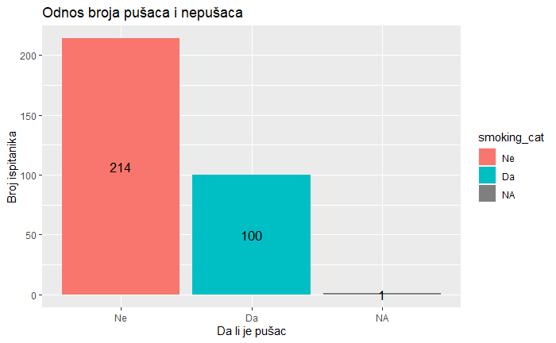

```r
ggplot(data = data, aes(x = smoking_cat)) +
  geom_bar(stat = "count",mapping = aes(fill=smoking_cat)) +
  stat_count(geom = "text", colour = "black", size = 4.5, aes(label = ..count..), position = position_stack(vjust = 0.5))+
  labs(title = "Odnos broja pušača i nepušača",
       x = "Da li je pušač",
       y = "Broj ispitanika")
```

Sa grafika uočavamo da više od dve trećine ispitanika nisu pušači.

## Numeričke promenljive

### Starost

```r
xtabs(~age, data=data)
```

```
age
    40     41     42     43     44     45     46     47     48     49     50     51     52     53     54     55     56
     9      1      7      1      2     20      4      1      3      4     28      5      6     10      2     17      1
    57     58     59     60 60.667     61     62     63     64     65     66     67     68     69     70     72     73
     2     10      4     34      2      5      5      8      3     27      2      2      6      3     25      8      4
    75     76     77     78     79     80     81     82     85     86     87     90     94     95
    12      1      2      2      1      7      1      3      6      1      1      3      1      2
```

Uz pomoć **xtabs** funkcije mozemo da pogledamo neke vrednosti atributa age. Iz prikaza se moze videti da je zabeleženi broj godina za dva ispitanika iznosi 60.667. Kako nije praksa da se godine izražavaju u vidu realnih brojeva, prevešćemo ih u cele brojeve i posmatraćemo da pomenuti ispitanici imaju 60 godina.

```r
data$age[data$age==60.667] = 60
xtabs(~age, data=data)
```

```
age
40 41 42 43 44 45 46 47 48 49 50 51 52 53 54 55 56 57 58 59 60 61 62 63 64 65 66 67 68 69 70 72 73 75 76 77 78 79 80
 9  1  7  1  2 20  4  1  3  4 28  5  6 10  2 17  1  2 10  4 36  5  5  8  3 27  2  2  6  3 25  8  4 12  1  2  2  1  7
81 82 85 86 87 90 94 95
 1  3  6  1  1  3  1  2
```

Možemo pogledati i raspored vrednosti ove kolone:

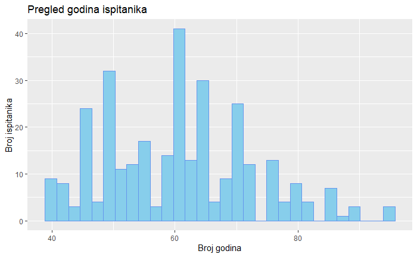

```r
ggplot(data = data, mapping = aes(x = age)) + geom_histogram(fill="skyblue", color="cornflowerblue", bins = 30) + labs(title = "Pregled godina ispitanika", x = "Broj godina", y = "Broj ispitanika")
```

Kako imamo i factor promenljivu za godine ispitanika, pogledaćemo i koliko ispitanika imamo po starosnim grupama.

```r
xtabs(~age_cat, data=data)
```

```
age_cat
40-50 51-65 66-75   75+
   80   141    62    31
```

Vidimo da najmanje ispitanika imamo u grupi od 75+ godina, a najviše u grupi od 51 do 65 godina.

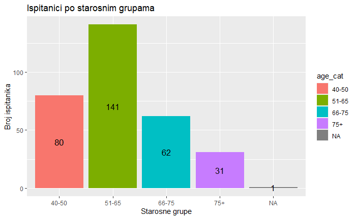

```r
ggplot(data = data, aes(x = age_cat)) +
  geom_bar(stat = "count",mapping = aes(fill=age_cat)) +
  stat_count(geom = "text", colour = "black", size = 4.5, aes(label = ..count..), position = position_stack(vjust = 0.5))+
  labs(title = "Ispitanici po starosnim grupama",
       x = "Starosne grupe",
       y = "Broj ispitanika")
```

### CPK enzim u krvi

```r
xtabs(~creatinine_phosphokinase, data=data)
```

```
creatinine_phosphokinase
   0   23   30   47   52   53   54   55   56   57   58   59   60   61   62   63   64   66   68   69   70   72   75
   2    1    1    3    1    1    1    1    2    1    1    3    3    2    1    1    3    4    3    3    1    1    1
  76   78   80   81   84   86   88   90   91   92   93   94   95   96   97   99  101  102  103  104  109  110  111
   1    2    2    2    3    1    1    1    1    1    1    1    2    2    1    1    1    2    1    1    2    1    1
 112  113  115  118  119  121  122  123  124  125  127  128  129  130  131  132  133  135  143  144  145  146  148
   1    2    3    1    1    1    2    1    1    1    1    1    4    1    1    2    1    2    2    1    1    2    2
 149  151  154  156  157  159  160  161  166  167  168  170  171  176  180  185  190  191  193  196  198  200  203
   1    1    1    1    2    1    1    1    1    2    2    1    1    1    1    1    1    1    1    2    1    1    1
 207  211  212  213  220  224  231  232  233  235  244  245  246  248  249  250  253  257  258  260  270  280  281
   1    1    2    1    1    2    3    1    1    1    1    1    2    1    1    2    1    1    1    1    1    1    1
 291  292  298  300  305  308  315  318  320  326  328  335  336  337  358  364  369  371  379  395  400  418  427
   1    1    1    1    1    1    1    1    1    1    1    1    1    1    1    1    1    1    1    1    1    1    1
 446  478  482  514  553  571  572  577  582  588  607  615  618  624  646  655  675  707  719  720  737  748  754
   1    1    1    1    1    1    1    1   52    1    1    1    2    1    1    1    1    1    1    1    1    1    1
 776  789  805  835  855  892  897  898  910  936  943  972  981 1021 1051 1082 1185 1199 1202 1211 1380 1419 1548
   1    1    1    2    1    1    1    1    1    1    1    1    1    1    1    1    1    1    1    1    1    1    1
1610 1688 1767 1808 1820 1846 1876 1896 2017 2060 2261 2281 2334 2413 2440 2442 2522 2656 2695 2794 3964 3966 4540
   1    1    1    1    1    1    1    1    1    1    1    1    1    1    1    1    1    1    1    1    1    1    1
5209 5882 5890 7702 7861
   1    1    1    2    1
```

Iznad je prikazan pregled postojećih vrednosti za CPK enzim u krvi ispitanika.

Možemo primetiti i da je nivo CPK enzima za 2 ispitanika iznosi **0 mcg/L**. Kako ova vrednost nije moguća, pretvorićemo je u nedostajuću i kasnije dodeliti neku konkretnu vrednost.

```r
data$creatinine_phosphokinase[data$creatinine_phosphokinase==0] <- NA
```

Provera nedostajućih vrednosti:

```r
length(which(is.na(data$creatinine_phosphokinase)))
```

```
[1] 2
```

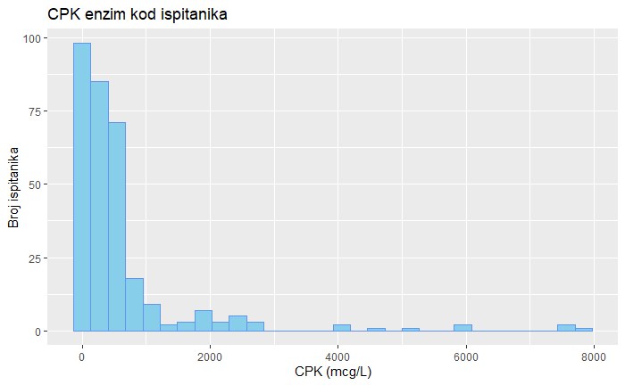

```r
ggplot(data = data, mapping = aes(x = creatinine_phosphokinase)) + geom_histogram(fill="skyblue", color="cornflowerblue", bins = 30) + labs(title = "CPK enzim kod ispitanika", x = "CPK (mcg/L)", y = "Broj ispitanika")
```

Sa prikazanog histograma možemo zaključiti da najveći broj ispitanika ima CPK do 1000 mcg/L (grubo rečeno). Možemo primetiti i da imamo neke vrlo visoke vrednosti ovog parametra, što potencijalno mogu biti outlier-i. Proverićemo ovo u odeljku **Izuzeci**.

### Ejekciona frakcija

Kao što je napomenuto u uvodu, autribut **ejection_fraction** predstavlja procenat krvi koja napušta srce pri svakoj kontrakciji. Kako su vrednosti date u vidu procenata, za očekivati je da one mogu biti u opsegu od 0 do 100, a uzimajući u obzir da je u pitanju parametar vezan za ljudski organizam, znamo takođe da vrednosti ne mogu biti drastično niske ili drastično visoke u ovom opsegu. Pogledaćemo postojeće vrednosti uz pomoć **xtabs**:

```r
xtabs(~ejection_fraction, data=data)
```

```
ejection_fraction
14 15 17 20 25 30 35 37 38 40 42 45 50 55 60 62 65 70 80
 1  3  2 21 37 35 49  1 41 38  1 20 22  4 32  2  1  1  1
```

```r
summary(data$ejection_fraction)
```

```
   Min. 1st Qu.  Median    Mean 3rd Qu.    Max.    NA's
  14.00   30.00   38.00   37.95   45.00   80.00       3
```

U skladu sa očekivanjima, minimalna vrednost atributa iznosi 14, a maksimalna 80.

Normalne vrednosti ovog parametra iznose **između 50% i 75%**. Kako ovaj procenat opada, to se srčana insuficijencija pogoršava. EF ispod 30% predstavlja relativno ozbiljnu oslabljenost srca, dok 20% ili niže predtavlja veoma tešku srčanu insuficijenciju. EF iznad 75% smatra se previsokim i takođe predstavlja zaseban problem, jer može dovesti do srčanog zastoja.

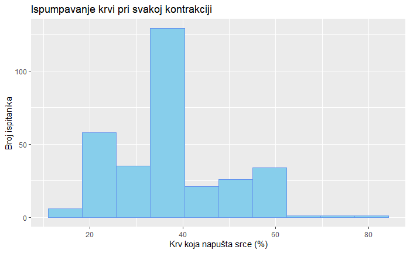

```r
ggplot(data = data, mapping = aes(x = ejection_fraction)) + geom_histogram(fill="skyblue", color="cornflowerblue", bins = 10) + labs(title = "Ispumpavanje krvi pri svakoj kontrakciji", x = "Krv koja napušta srce (%)", y = "Broj ispitanika")
```

Sa histograma možemo zaključiti da najveći broj ispitanika ima EF **između 20% i 40%**, što zaista predstavlja oslabljen rad srca koji vodi ka njegovom otkazivanju. Takođe, ono što se može videti sa grafika i preko funkcija **xtabs** i **summary**, jeste da deo ispitanika ima ove vrednosti u granicama normale, ili vrednosti koje su pak povišene.

### Trombociti u krvi

Trombociti (krvne ploče) su krvne ćelije čija je glavna uloga u hemostazi tj. zaustavljanju krvarenja prilikom povrede krvog suda.

```r
summary(data$platelets)
```

```
   Min. 1st Qu.  Median    Mean 3rd Qu.    Max.
  25100  211500  263000  273547  305000 2790000
```

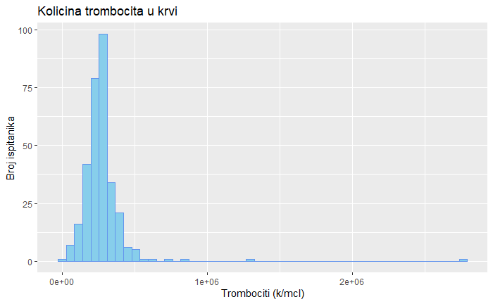

```r
ggplot(data=data) +
  geom_histogram(fill = "skyblue", color = "cornflowerblue",aes(x=platelets), bins=50)+
  labs(title = "Količina trombocita u krvi",
       x = "Trombociti (k/mcl)",
       y = "Broj ispitanika")
```

Možemo primetiti da imamo manji broj vrednosti za trombocite koje su izuzetno velike. Da pogledamo.

```r
data$platelets[which(data$platelets>1e+06)]
```

```
[1] 1270000 2790000
```

```r
which(data$platelets>1e+06)
```

```
[1] 302 307
```

```r
data[which(data$platelets>1e+06),]
```

|  | age | anaemia | creatinine_phosphokinase | diabetes | ejection_fraction | high_blood_pressure | platelets | serum_creatinine | serum_sodium | sex | smoking | time | DEATH_EVENT | anaemia_cat | diabetes_cat | high_blood_pressure_cat | sex_cat | smoking_cat | DEATH_EVENT_cat | age_cat |
| --- | --- | --- | --- | --- | --- | --- | --- | --- | --- | --- | --- | --- | --- | --- | --- | --- | --- | --- | --- | --- |
| 302 | 75 | 1 | 246 | 0 | 15 | 0 | 1270000 | 1.2 | 137 | 1 | 0 | 10 | 1 | Ima anemiju | Nema dijabetes | Nema povišen krvni pritisak | M | Ne | Preminuo | 66-75 |
| 307 | 50 | 1 | 5890 | 1 | 20 | 1 | 2790000 | 1.0 | 134 | 0 | 0 | 186 | 0 | Ima anemiju | Ima dijabetes | Ima povišen krvni pritisak | Ž | Ne | Nije preminuo | 40-50 |

Na osnovu domenskog znanja možemo zaključiti da se najverovatnije radi o grešci prilikom unosa podataka. Oba ispitanika su anemični, što dovodi do smanjenja broja trombocita u nekim slučajevima. Takodje, broj trombocita u krvi sa kreće u stotinama hiljada čak i kada je povišen broj. Zaključujemo da je najverovatnije uneta nula više, što ćemo ispraviti.

```r
data$platelets[which(data$platelets>1e+06)] = data$platelets[which(data$platelets>1e+06)]/10
```

Provera:

```r
data$platelets[c(302,307)]
```

```
[1] 127000 279000
```

```r
summary(data$platelets)
```

```
   Min. 1st Qu.  Median    Mean 3rd Qu.    Max.
  25100  210500  262000  261947  304000  850000
```

Nacrtaćemo ponovo graf.

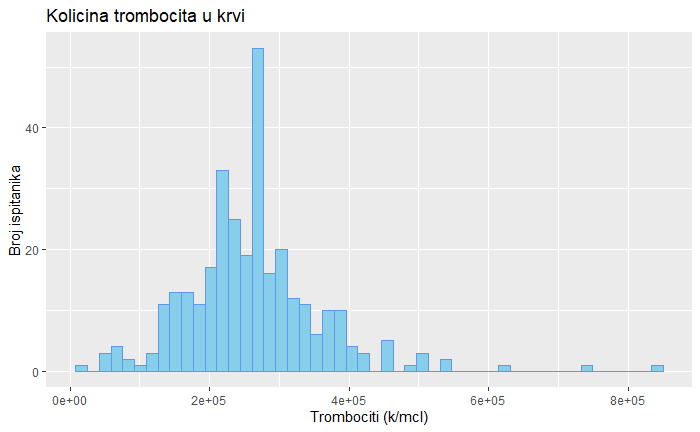

```r
ggplot(data=data) +
  geom_histogram(fill = "skyblue", color = "cornflowerblue",aes(x=platelets), bins=50)+
  labs(title = "Količina trombocita u krvi",
       x = "Trombociti (k/mcl)",
       y = "Broj ispitanika")
```

Uočavamo nesvakidašnje vrednosti koje su relativno bliske nuli kao i vrednosti koje su dosta velike (preko 600000). Iako neobične, nisu nemoguće pa ćemo se dalje baviti njima u odeljku **Izuzeci** gde ćemo ispitati da li su outlier-i.

### Kreatinin u krvi

Kreatinin je hemijsko jedinjenje koje nastaje tokom procesa stvaranja energije u mišićima. Kako se zadržava u krvi, a tu je nepotrebna (čak i škodno ukoliko se nalazi u velikim količinama), naši bubrezi je filtriraju. Dobar je pokazatelj koliko zdravlja i funkcionalnosti bubrega.

```r
summary(data$serum_creatinine)
```

```
   Min. 1st Qu.  Median    Mean 3rd Qu.    Max.    NA's
   0.00    0.90    1.10    1.38    1.40    9.40       2
```

```r
length(which(is.na(data$serum_creatinine)))
```

```
[1] 2
```

Uočavamo da postoji dve nepoznate vrednosti za kreatinin.

Nacrtaćemo grafik:

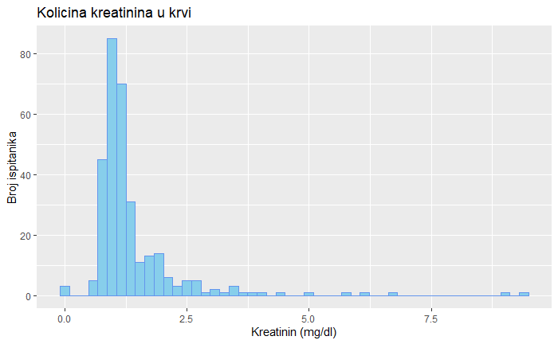

```r
ggplot(data=data) +
  geom_histogram(aes(x=serum_creatinine), bins=50,fill = "skyblue", color = "cornflowerblue")+
  labs(title = "Količina kreatinina u krvi",
       x = "Kreatinin (mg/dl)",
       y = "Broj ispitanika")
```

Na grafiku postoje vrednosti za kreatinin koje su 0, što je nemoguće. Te vrednosti zamenićemo sa NA.

```r
which(data$serum_creatinine==0)
```

```
[1] 309 310 314
```

```r
data$serum_creatinine[which(data$serum_creatinine==0)] = NA
```

Prikazaćemo graf nakon izmena:

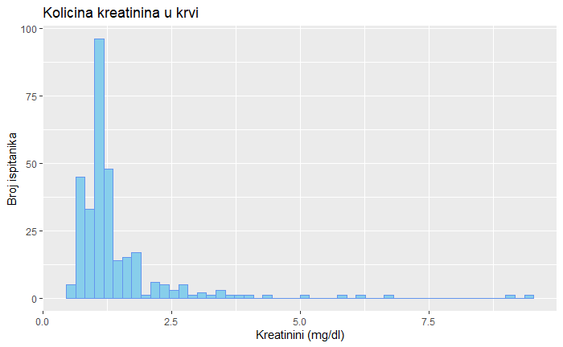

```r
ggplot(data=data) +
  geom_histogram(aes(x=serum_creatinine), bins=50,fill = "skyblue", color = "cornflowerblue")+
  labs(title = "Količina kreatinina u krvi",
       x = "Kreatinini (mg/dl)",
       y = "Broj ispitanika")
```

Na grafu iznad, uočavamo veoma visoke količine kreatinina u krvi. Iako neuobičajene, nisu nemoguće, pa ćemo u delu **Izuzeci** ispitati da li su te outlier-i ili ne.

```r
data$serum_creatinine[which(data$serum_creatinine>5)]
```

```
[1] 9.4 5.8 6.8 6.1 9.0
```

```r
which(data$serum_creatinine>5)
```

```
[1]  10  29  53 132 218
```

### Natrijum u krvi

Natrijum u organizmu učestvuje u velikom broju procesa od kojih su za naš rad najbitniji regulisanje krvnog pritiska i održavanje normalnog rada srčanog mišića.

```r
summary(data$serum_sodium)
```

```
   Min. 1st Qu.  Median    Mean 3rd Qu.    Max.
  113.0   134.0   137.0   136.5   139.5   148.0
```

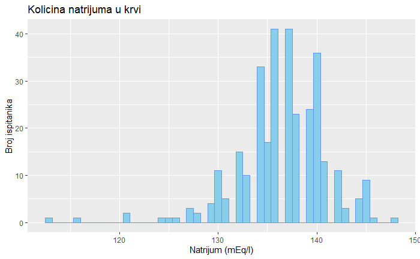

```r
ggplot(data=data) +
  geom_histogram(aes(x=serum_sodium), bins=50,fill = "skyblue", color = "cornflowerblue")+
  labs(title = "Količina natrijuma u krvi",
       x = "Natrijum (mEq/l)",
       y = "Broj ispitanika")
```

Uočavamo na grafiku da postoji mali broj ispitanika sa nivoima natrijuma nešto višim i dosta nižim od većine ostalih ispitanika. U delu **Izuzeci** ćemo proveriti da li su u pitanju outlier-i.

### Propratni period posmatranja

```r
length(which(is.na(data$time)))
```

```
[1] 2
```

Postoje dve NA vrednosti za propratni period.

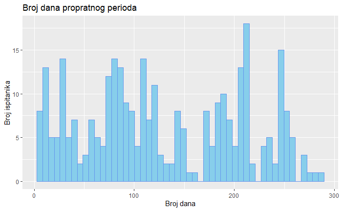

```r
ggplot(data=data) +
  geom_histogram(fill = "skyblue", color = "cornflowerblue",aes(x=time), bins=50)+
  labs(title = "Broj dana propratnog perioda",
       x = "Broj dana",
       y = "Broj ispitanika")
```

# Rad sa nedostajućim vrednostima

Pogledaćemo u kojim kolonama imamo nedostajuće vrednosti:

```r
sapply(data[,1:13], function(x) sum(is.na(x)))
```

```
                     age                  anaemia creatinine_phosphokinase                 diabetes
                       1                        2                        2                        0
       ejection_fraction      high_blood_pressure                platelets         serum_creatinine
                       3                        0                        0                        5
            serum_sodium                      sex                  smoking                     time
                       0                        3                        1                        2
             DEATH_EVENT
                       0
```

Posmatramo samo 13 originalnih kolona. Ostale su dodate tokom rada i predstavljaju njihov duplikat pa su samim tim ovde suvišne.

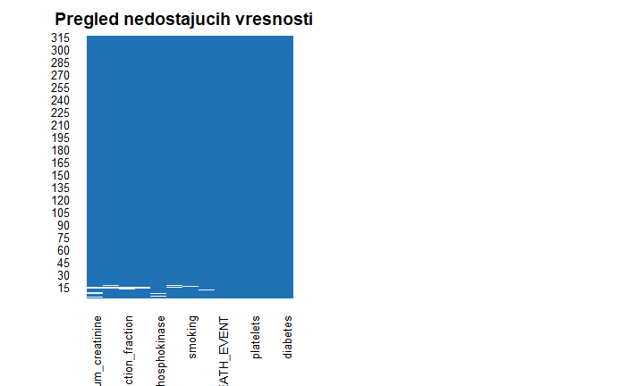

```r
par(mfrow=c(1,2))
missmap(obj = data[,1:13], main = "Pregled nedostajućih vresnosti   ", legend = FALSE)
par(mfrow=c(1,1))
```

Proverićemo, takođe, da li u redovima u kojima postoji nedostajuća vrednost ima više kolona sa nedostajućim vrednostima:

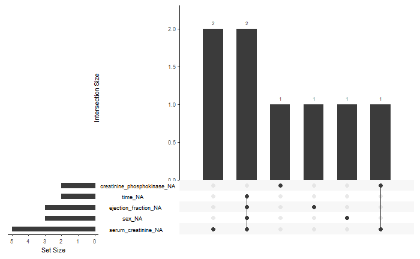

```r
gg_miss_upset(data[,1:13])
```

```r
data[which(is.na(data$time)),1:13]
```

|  | age | anaemia | creatinine_phosphokinase | diabetes | ejection_fraction | high_blood_pressure | platelets | serum_creatinine | serum_sodium | sex | smoking | time | DEATH_EVENT |
| --- | --- | --- | --- | --- | --- | --- | --- | --- | --- | --- | --- | --- | --- |
| 303 | 48 | NA | 582 | 1 | NA | 0 | 87000 | NA | 121 | NA | 0 | NA | 1 |
| 304 | 51 | 0 | 78 | 0 | NA | 0 | 406000 | NA | 140 | NA | 0 | NA | 0 |

Pregled nedostajućih vrednosti nakon uklanjanja redova:

```r
data = data[-which(is.na(data$time)),]
```

```r
sapply(data[,1:13], function(x) sum(is.na(x)))
```

```
                     age                  anaemia creatinine_phosphokinase                 diabetes
                       1                        1                        2                        0
       ejection_fraction      high_blood_pressure                platelets         serum_creatinine
                       1                        0                        0                        3
            serum_sodium                      sex                  smoking                     time
                       0                        1                        1                        0
             DEATH_EVENT
                       0
```

## Kategorijske promenljive sa malim brojem nedostajućih vrednosti

### Anemija

```r
length(which(is.na(data$anaemia)))
```

```
[1] 1
```

Imamo jednu nedostajuću vrednost za anemiju. Pogledaćemo taj red.

```r
data[which(is.na(data$anaemia)),1:13]
```

|  | age | anaemia | creatinine_phosphokinase | diabetes | ejection_fraction | high_blood_pressure | platelets | serum_creatinine | serum_sodium | sex | smoking | time | DEATH_EVENT |
| --- | --- | --- | --- | --- | --- | --- | --- | --- | --- | --- | --- | --- | --- |
| 300 | 76 | NA | 582 | 0 | 20 | 1 | 265000 | 0.8 | 130 | NA | 0 | 4 | 0 |

Uglavnom kada imamo mali broj nedostajućih vrednosti kod neke kategorijske promenljive, praksa je da se one zamene najdominantnijom klasom. To u ovom slučaju možemo bez problema uraditi, jer jedna vrednost neće imati bitan uticaj na nastavak rada sa skupom i predviđanje.

```r
xtabs(~anaemia_cat, data=data)
```

```
anaemia_cat
Nema anemiju  Ima anemiju
         178          134
```

Možemo primetiti da većina ispitanika nema anemiju, što bi značilo da i za posmatranog ispitanika možemo da pretpostavimo da nema anemiju. Ali kako znamo da anemija utiče na broj trombocita u krvi, kao i da anemija može biti izazvana ako je kreatinin visok, možemo na osnovu ova dva parametra preciznije odrediti da li ispitanik ima ili nema anemiju. Ispitanik ima 265000 trombocita i vrednost 0.8 za kreatinin.

Znamo da broj trombocita u krvi koji je ispod 140000 obično ukazuje na anemiju. Naš ispitanik ima skoro duplo više, što već samo po sebi govori da verovatno nema anemiju. Sa druge strane, vrednosti kreatinina u krvi koje se smatraju normalnim razlikuju se u zavisnosti od pola. Kod žena, normalan opseg iznosi 0.59-1.04 mg/dl, a kod muškaraca 0.74-1.35 mg/dl. Osoba koju posmatramo nema zabeležen pol, ali kako je vrednost kreatinina 0.8, ta vrednost se smatra normalnom i kod muškaraca i kod žena, pa i prema ovom parametru možemo pretpostaviti da osoba nema anemiju. Možemo preći na zamenu NA ovom klasom i za originalnu kolonu, i za njoj ekvivalentnu kategorijsku kolonu.

```r
data$anaemia[is.na(data$anaemia)] = 0
```

Provera:

```r
length(which(is.na(data$anaemia)))
```

```
[1] 0
```

Kategorijska kolona i dalje ima nedostajuću vrednost, zamenićemo i nju.

```r
length(which(is.na(data$anaemia_cat)))
```

```
[1] 1
```

```r
data$anaemia_cat[is.na(data$anaemia_cat)] = "Nema anemiju"
```

Provera:

```r
length(which(is.na(data$anaemia_cat)))
```

```
[1] 0
```